# Exponential Random Graph Models (ERGMs) using statnet

Statnet Development Team

*Last updated 2018-06-25*

*This tutorial is a joint product of the Statnet Development Team:*

Martina Morris (University of Washington)  
Steven M. Goodreau (University of Washington)  
Mark S. Handcock (University of California, Los Angeles)  
Carter T. Butts (University of California, Irvine)  
David R. Hunter (Penn State University)  
Skye Bender de-Moll (Oakland)  
Pavel N. Krivitsky (University of Wollongong)

For general questions and comments, please refer to the `statnet` users group and mailing list  
http://statnet.csde.washington.edu/statnet_users_group.shtml

## Introduction to this workshop/tutorial.

This workshop and tutorial provide an overview of statistical modeling of network data with *Exponential family Random Graph Models* (ERGMs) using `statnet` software. This online tutorial is also designed for self-study, with example code and self-contained data. The `statnet` packages we will be demonstrating are:

- `network` – storage and manipulation of network data
- `sna` – descriptive statistics and graphics for exploratory network analysis`
- `ergm` – statistical tools for estimating ERGMs, model assessment, and network simulation.

All `statnet` packages are open-source, written for the **R** computing environment, and published on CRAN. The source repositories are hosted on GitHub.

### Prerequisites

This workshop assumes basic familiarity with **R**, experience with network concepts, terminology and data, and familiarity with the general framework for statistical modeling and inference. While previous experience with ERGMs is not required, some of the topics covered here may be difficult to understand without a strong background in linear and generalized linear models in statistics.

### Software installation

Minimally, you will need to install the latest version of **R** [(available here)](https://cran.r-project.org) and the `statnet` packages above to run the code presented here.  
The workshops are conducted using the free version of `Rstudio` [(available here)](https://rstudio.org).

To install the packages for this tutorial, open an R session and type:

```r
install.packages(c('statnet', 'sna'))
library(statnet)
```

Note that the ‘statnet’ package is actually a wrapper that automatically installs the most commonly used packages in the statnet suite, so this will include more packages than we will be using in this tutorial. You can install just the individual packages if you prefer.

For this tutorial, we will use one more package (latticeExtra), which is recommended (but not required) by ergm:

```r
install.packages('latticeExtra')
require(latticeExtra)
```

Set a seed for simulations – this is not necessary, but it ensures that you will get the same results as the online tutorial (if we execute the same commands in the same order).

```r
set.seed(0)
```

## 1. Statistical network modeling with ERGMs

Exponential-family random graph models (ERGMs) represent a general class of models based in exponential-family theory for specifying the probability distribution for a set of random graphs or networks. Within this framework, one can—among other tasks—obtain maximum-likehood estimates for the parameters of a specified model for a given data set; test individual models for goodness-of-fit, perform various types of model comparison; and simulate additional networks with the underlying probability distribution implied by that model.

The general form for an ERGM can be written as:

$$P(Y=y)=\frac{\exp(\theta'g(y))}{k(\theta)}$$

where $Y$ is the random variable for the state of the network (with realization $y$), $g(y)$ is a vector of model statistics for network $y$, $\theta$ is the vector of coefficients for those statistics, and $k(\theta)$ represents the quantity in the numerator summed over all possible networks (typically constrained to be all networks with the same node set as $y$).

This can be re-expressed in terms of the conditional log-odds of a single tie between two actors:

$$\operatorname{logit}{(Y_{ij}=1|y^{c}_{ij})=\theta'\delta(y_{ij})}$$

where $Y_{ij}$ is the random variable for the state of the actor pair $i,j$ (with realization $y_{ij}$), and $y^{c}_{ij}$ signifies the complement of $y_{ij}$, i.e. all dyads in the network other than $y_{ij}$. The vector $\delta(y_{ij})$ contains the “change statistic” for each model term. The change statistic records how $g(y)$ term changes if the $y_{ij}$ tie is toggled on or off. So:

$$\delta(y_{ij}) = g(y^{+}_{ij})-g(y^{-}_{ij})$$

where $y^{+}_{ij}$ is defined as $y^{c}_{ij}$ along with $y_{ij}$ set to 1, and $y^{-}_{ij}$ is defined as $y^{c}_{ij}$ along with $y_{ij}$ set to 0. That is, $\delta(y_{ij})$ equals the value of $g(y)$ when $y_{ij}=1$ minus the value of $g(y)$ when $y_{ij}=0$, but all other dyads are as in $g(y)$.

This emphasizes that the coefficient $\theta$ can be interpreted as the log-odds of an individual tie conditional on all others.

The model terms $g(y)$ in an ERGM are *network statistics*, functions of network configurations that we hypothesize may be more or less common than what would be expected in a simple random graph (where all ties have the same probability). For example, specific degree distributions, triad configurations, or homophily on nodal attributes. Unlike traditional covariates in a linear model, network statistics are not exogenous measures, they are functions of the network itself, typically sums of dyad states or products of dyad states that represent specific configurations.

We will explore some of these terms in this tutorial, and links to more information are provided in section 3.

One key distinction in model terms is worth keeping in mind: terms are either *dyad independent* or *dyad dependent*. Dyad independent terms (like nodal homophily terms) imply no dependence between dyads—the presence or absence of a tie may depend on nodal attributes, but not on the state of other ties. Dyad dependent terms (like degree terms, or triad terms), by contrast, imply dependence between dyads. Such terms have very different effects, and much of what is different about network models comes from the complex cascading effects that these terms introduce. A model with dyad dependent terms also requires a different estimation algorithm, and you will see some different components in the output.

### The `summary` and `ergm` functions, and supporting functions

We’ll start by running some simple models to demonstrate the most commonly used functions for ERG modeling.

The ergm package contains several network data sets that we will use for demonstration purposes.

```r
data(package='ergm') # tells us the datasets in our packages
```

We’ll use Padgett’s data on Renaissance Florentine families for this example. As with all data analysis, we start by looking at our data: using graphical and numerical descriptives.

```r
data(florentine) # loads flomarriage and flobusiness data
flomarriage # Look at the flomarriage network properties (uses `network`)
```

```
 Network attributes:
  vertices = 16
  directed = FALSE
  hyper = FALSE
  loops = FALSE
  multiple = FALSE
  bipartite = FALSE
  total edges= 20
    missing edges= 0
    non-missing edges= 20

 Vertex attribute names:
    priorates totalties vertex.names wealth

No edge attributes
```

```r
par(mfrow=c(1,2)) # Setup a 2 panel plot
plot(flomarriage, main="Florentine Marriage",
     cex.main=0.8,
     label = network.vertex.names(flomarriage)) # Plot the network
wealth <- flomarriage %v% 'wealth' # %v% references vertex attributes
wealth
```

```
 [1]  10  36  55  44  20  32   8  42 103  48  49   3  27  10 146  48
```

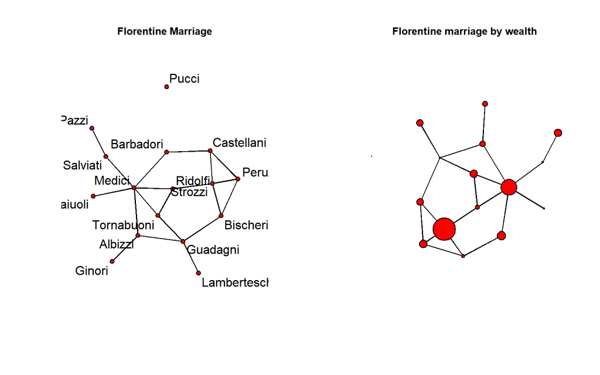

```r
plot(flomarriage, vertex.cex=wealth/25, main="Florentine marriage by wealth", cex.main=0.8) # Plot the network with vertex size proportional to wealth
```

The syntax for specifying a model in the `ergm` package follows **R**’s formula convention:

$$my.network \sim my.vector.of.model.terms$$

This syntax is used for both the `summary` and `ergm` functions. The `summary` function simply returns the numerical values of the network statistics in the model. The `ergm` function estimates the model with those statistics.

#### A simple Bernoulli (“Erdos/Renyi”) model

We begin with the simplest possible model, it contains only one term that represents the overall density of the network. The ergm-term for this is `edges`.

```r
summary(flomarriage ~ edges) # Look at the $g(y)$ statistic for this model
```

```
edges
   20
```

```r
flomodel.01 <- ergm(flomarriage ~ edges) # Estimate the model
```

```
Evaluating log-likelihood at the estimate.
```

```r
summary(flomodel.01) # Look at the fitted model object
```

```
==========================
Summary of model fit
==========================

Formula:   flomarriage ~ edges

Iterations:  5 out of 20

Monte Carlo MLE Results:
      Estimate Std. Error MCMC % p-value
edges  -1.6094     0.2449      0  <1e-04 ***
---
Signif. codes:  0 '***' 0.001 '**' 0.01 '*' 0.05 '.' 0.1 ' ' 1

     Null Deviance: 166.4  on 120  degrees of freedom
 Residual Deviance: 108.1  on 119  degrees of freedom

AIC: 110.1    BIC: 112.9    (Smaller is better.)
```

Note that the network statistic `edges` is the number of ties in the network – $\sum{y_{ij}}$.

This simple model specifies a single homogeneous probability for all ties, which is captured by the coefficient on the `edges` term.  
How should we interpret this coefficient? The easiest way is to return to the logit form of the ERGM. The log-odds that a tie is present is:

$$\small{
\begin{eqnarray*}
logit(p(y)) &=& \theta \times \delta(g(y)) \\
& = & -1.609 \times \mbox{change in the number of ties}\\
& = & -1.609 \times 1
\end{eqnarray*}
}$$

for every tie, since the addition of any tie to the network always increases the total number of ties by 1.

The corresponding probability is obtained by taking the expit of $\theta$:

$$\small{
\begin{eqnarray*}
& = & \exp(-1.609)/(1+\exp(-1.609))\\
& = & 0.1667
\end{eqnarray*}
}$$

Note that corresponds to the density we observe in the flomarriage network: there are 20 ties and (16 choose 2 = 16*15/2 =) 120 dyads.

#### Triad formation

Let’s add a term often thought to be a measure of “clustering”: the number of completed triangles.  
The ergm-term for this is `triangle`. This is an example of a dyad dependent term: the status of dyad $y_{ij}$ depends on the status of two other dyads, $y_{ik}$ and $y_{jk}$. As a result, the estimation algorithm automatically changes to MCMC, and because this is a form of stochastic estimation your results may differ slightly.

```r
summary(flomarriage~edges+triangle) # Look at the g(y) stats for this model
```

```
   edges triangle
      20        3
```

```r
flomodel.02 <- ergm(flomarriage~edges+triangle)
summary(flomodel.02)
```

```
==========================
Summary of model fit
==========================

Formula:   flomarriage ~ edges + triangle

Iterations:  2 out of 20

Monte Carlo MLE Results:
         Estimate Std. Error MCMC % p-value
edges     -1.6761     0.3485      0  <1e-04 ***
triangle   0.1469     0.5668      0   0.796
---
Signif. codes:  0 '***' 0.001 '**' 0.01 '*' 0.05 '.' 0.1 ' ' 1

     Null Deviance: 166.4  on 120  degrees of freedom
 Residual Deviance: 108.1  on 118  degrees of freedom

AIC: 112.1    BIC: 117.6    (Smaller is better.)
```

The network statistic `triangle` is the number of defined as the number of triangles in the network – $\sum{y_{ij}y_{ik}y_{jk}} \div 3$.

Now, how should we interpret coefficients?

The conditional log-odds of two actors having a tie is:

$$\small{
-1.67\times\mbox{change in the number of ties}+0.14\times\mbox{change in number of triangles}
}$$

- For a tie that will create no triangles, the conditional log-odds is: $-1.67$.
- if one triangle: $-1.67 + 0.14 =-1.53$
- if two triangles: $-1.67 +0.14\times2=-1.39$
- the corresponding probabilities are 0.16, 0.18, and 0.20.

Let’s take a closer look at the ergm object itself:

```r
class(flomodel.02) # this has the class ergm
```

```
[1] "ergm"
```

```r
names(flomodel.02) # the ERGM object contains lots of components.
```

```
 [1] "coef"          "sample"        "sample.obs"    "iterations"
 [5] "MCMCtheta"     "loglikelihood" "gradient"      "hessian"
 [9] "covar"         "failure"       "network"       "newnetworks"
[13] "newnetwork"    "coef.init"     "est.cov"       "coef.hist"
[17] "stats.hist"    "steplen.hist"  "control"       "etamap"
[21] "formula"       "target.stats"  "target.esteq"  "constrained"
[25] "constraints"   "reference"     "estimate"      "offset"
[29] "drop"          "estimable"     "null.lik"      "mle.lik"
```

```r
flomodel.02$coef # you can extract/inspect individual components
```

```
     edges   triangle
-1.6760880  0.1468579
```

#### Nodal covariates: effects on mean degree

We can test whether edge probabilities are a function of wealth. This is a nodal covariate, so we use the ergm-term **nodecov**.

```r
summary(wealth) # summarize the distribution of wealth
```

```
   Min. 1st Qu.  Median    Mean 3rd Qu.    Max.
   3.00   17.50   39.00   42.56   48.25  146.00
```

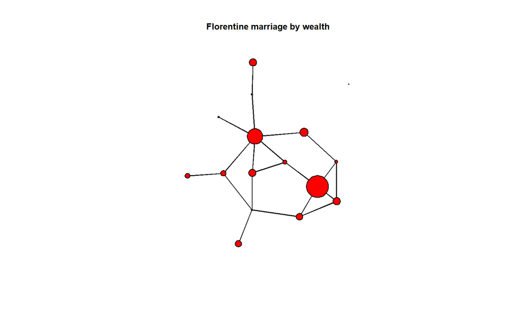

```r
plot(flomarriage, vertex.cex=wealth/25, main="Florentine marriage by wealth", cex.main=0.8) # network plot with vertex size proportional to wealth
```

```r
summary(flomarriage~edges+nodecov('wealth')) # observed statistics for the model
```

```
         edges nodecov.wealth
            20           2168
```

```r
flomodel.03 <- ergm(flomarriage~edges+nodecov('wealth'))
```

```
Evaluating log-likelihood at the estimate.
```

```r
summary(flomodel.03)
```

```
==========================
Summary of model fit
==========================

Formula:   flomarriage ~ edges + nodecov("wealth")

Iterations:  4 out of 20

Monte Carlo MLE Results:
                Estimate Std. Error MCMC % p-value
edges          -2.594929   0.536056      0  <1e-04 ***
nodecov.wealth  0.010546   0.004674      0  0.0259 *
---
Signif. codes:  0 '***' 0.001 '**' 0.01 '*' 0.05 '.' 0.1 ' ' 1

     Null Deviance: 166.4  on 120  degrees of freedom
 Residual Deviance: 103.1  on 118  degrees of freedom

AIC: 107.1    BIC: 112.7    (Smaller is better.)
```

Yes, there is a significant positive wealth effect on the probability of a tie.

How do we interpret the coefficients here? Note that the wealth effect operates on both nodes in a dyad. The conditional log-odds of a tie between two actors is:

$$\small{
-2.59\times\mbox{change in the number of ties} + 0.01\times\mbox{the wealth of node 1} + 0.01\times\mbox{the wealth of node 2}
}$$

$$\small{
-2.59\times\mbox{change in the number of ties} + 0.01\times\mbox{the sum of the wealth of the two nodes}
}$$

- for a tie between two nodes with minimum wealth, the conditional log-odds is:  
  $-2.59 + 0.01*(3+3) = -2.53$
- for a tie between two nodes with maximum wealth:  
  $-2.59 + 0.01*(146+146) = 0.33$
- for a tie between the node with maximum wealth and the node with minimum wealth:  
  $-2.59 + 0.01*(146+3) = -1.1$
- The corresponding probabilities are 0.07, 0.58, and 0.25.

Note: This model specification does not include a term for homophily by wealth. It just specifies a relation between wealth and mean degree. To specify homophily on wealth, you would use the ergm-term *absdiff* see section 3 below for more information on ergm-terms

#### Nodal covariates: Homophily

Let’s try a larger network, a simulated mutual friendship network based on one of the schools from the Add Health study. Here, we’ll examine the homophily in friendships by grade and race. Both are discrete attributes so we use the ergm-term *nodematch*.

```r
data(faux.mesa.high)
mesa <- faux.mesa.high
```

```r
mesa
```

```
 Network attributes:
  vertices = 205
  directed = FALSE
  hyper = FALSE
  loops = FALSE
  multiple = FALSE
  bipartite = FALSE
  total edges= 203
    missing edges= 0
    non-missing edges= 203

 Vertex attribute names:
    Grade Race Sex

No edge attributes
```

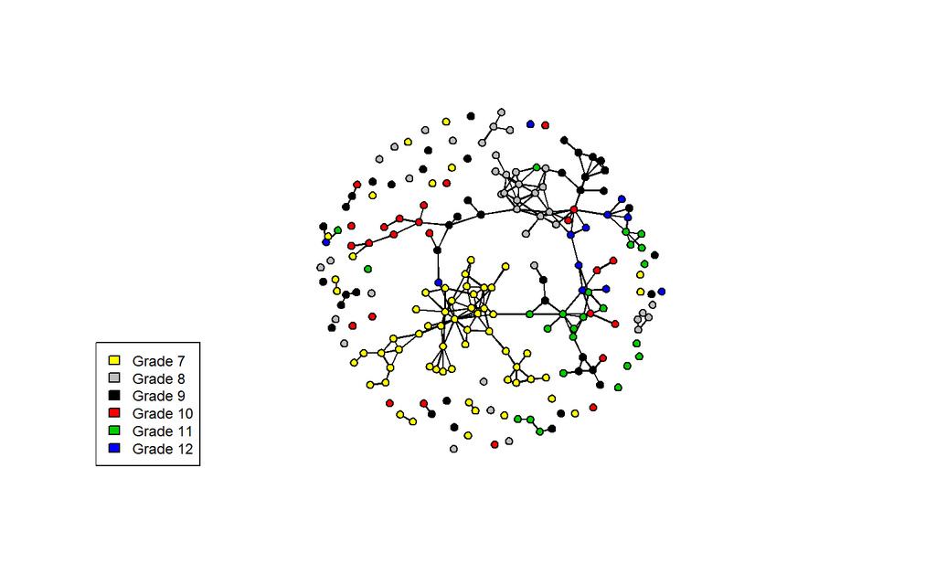

```r
par(mfrow=c(1,1)) # Back to 1-panel plots
plot(mesa, vertex.col='Grade')
legend('bottomleft',fill=7:12,legend=paste('Grade',7:12),cex=0.75)
```

```r
fauxmodel.01 <- ergm(mesa ~edges + nodematch('Grade',diff=T) + nodematch('Race',diff=T))
```

```
Observed statistic(s) nodematch.Race.Black and nodematch.Race.Other are at their smallest attainable values. Their coefficients will be fixed at -Inf.
```

```
Evaluating log-likelihood at the estimate.
```

```r
summary(fauxmodel.01)
```

```
==========================
Summary of model fit
==========================

Formula:   mesa ~ edges + nodematch("Grade", diff = T) + nodematch("Race",
    diff = T)

Iterations:  8 out of 20

Monte Carlo MLE Results:
                     Estimate Std. Error MCMC % p-value
edges                 -6.2328     0.1742      0  <1e-04 ***
nodematch.Grade.7      2.8740     0.1981      0  <1e-04 ***
nodematch.Grade.8      2.8788     0.2391      0  <1e-04 ***
nodematch.Grade.9      2.4642     0.2647      0  <1e-04 ***
nodematch.Grade.10     2.5692     0.3770      0  <1e-04 ***
nodematch.Grade.11     3.2921     0.2978      0  <1e-04 ***
nodematch.Grade.12     3.8376     0.4592      0  <1e-04 ***
nodematch.Race.Black     -Inf     0.0000      0  <1e-04 ***
nodematch.Race.Hisp    0.0679     0.1737      0  0.6959
nodematch.Race.NatAm   0.9817     0.1842      0  <1e-04 ***
nodematch.Race.Other     -Inf     0.0000      0  <1e-04 ***
nodematch.Race.White   1.2685     0.5371      0  0.0182 *
---
Signif. codes:  0 '***' 0.001 '**' 0.01 '*' 0.05 '.' 0.1 ' ' 1

     Null Deviance: 28987  on 20910  degrees of freedom
 Residual Deviance:  1928  on 20898  degrees of freedom

AIC: 1952    BIC: 2047    (Smaller is better.)

 Warning: The following terms have infinite coefficient estimates:
  nodematch.Race.Black nodematch.Race.Other
```

Note that two of the coefficients are estimated as -Inf (the nodematch coefficients for race Black and Other). Why is this?

```r
table(mesa %v% 'Race') # Frequencies of race
```

```
Black  Hisp NatAm Other White
    6   109    68     4    18
```

```r
mixingmatrix(mesa, "Race")
```

```
Note:  Marginal totals can be misleading
 for undirected mixing matrices.
      Black Hisp NatAm Other White
Black     0    8    13     0     5
Hisp      8   53    41     1    22
NatAm    13   41    46     0    10
Other     0    1     0     0     0
White     5   22    10     0     4
```

The problem is that there are very few students in the Black and Other race categories, and these few students form no within-group ties. The empty cells are what produce the -Inf estimates.

Note that we would have caught this earlier if we had looked at the $g(y)$ stats at the beginning:

```r
summary(mesa ~edges + nodematch('Grade',diff=T) + nodematch('Race',diff=T))
```

```
               edges    nodematch.Grade.7    nodematch.Grade.8
                 203                   75                   33
   nodematch.Grade.9   nodematch.Grade.10   nodematch.Grade.11
                  23                    9                   17
  nodematch.Grade.12 nodematch.Race.Black  nodematch.Race.Hisp
                   6                    0                   53
nodematch.Race.NatAm nodematch.Race.Other nodematch.Race.White
                  46                    0                    4
```

**Moral**: It’s a good idea to check the descriptive statistics of a model in the observed network before fitting the model.

See also the ergm-term *nodemix* for fitting mixing patterns other than homophily on discrete nodal attributes.

#### Directed ties

Let’s try a model for a directed network, and examine the tendency for ties to be reciprocated (“mutuality”). The ergm-term for this is *mutual*. We’ll fit this model to the third wave of the classic Sampson Monastery data, and we’ll start by taking a look at the network.

```r
data(samplk)
ls() # directed data: Sampson's Monks
```

```
 [1] "faux.mesa.high" "fauxmodel.01"   "flobusiness"    "flomarriage"
 [5] "flomodel.01"    "flomodel.02"    "flomodel.03"    "mesa"
 [9] "samplk1"        "samplk2"        "samplk3"        "wealth"
```

```r
samplk3
```

```
 Network attributes:
  vertices = 18
  directed = TRUE
  hyper = FALSE
  loops = FALSE
  multiple = FALSE
  bipartite = FALSE
  total edges= 56
    missing edges= 0
    non-missing edges= 56

 Vertex attribute names:
    cloisterville group vertex.names

No edge attributes
```

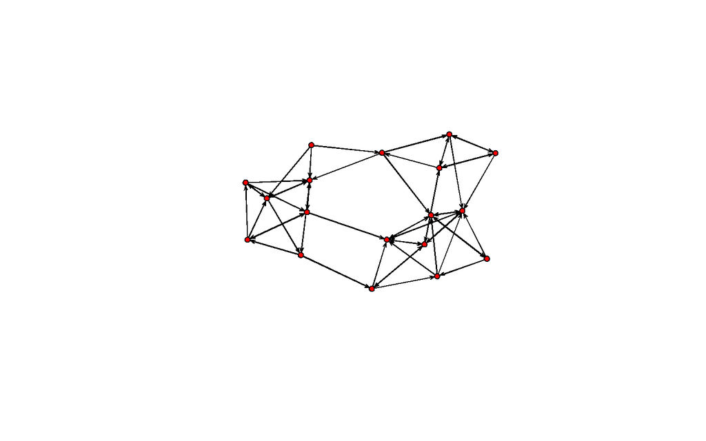

```r
plot(samplk3)
```

```r
summary(samplk3~edges+mutual)
```

```
 edges mutual
    56     15
```

The plot now shows the direction of a tie, and the $g(y)$ statistics for this model in this network are 56 total ties, and 15 mutual dyads (so 30 of the 56 ties are mutual ties).

```r
sampmodel.01 <- ergm(samplk3~edges+mutual)
summary(sampmodel.01)
```

```
==========================
Summary of model fit
==========================

Formula:   samplk3 ~ edges + mutual

Iterations:  2 out of 20

Monte Carlo MLE Results:
       Estimate Std. Error MCMC % p-value
edges   -2.1569     0.2158      0  <1e-04 ***
mutual   2.2997     0.4811      0  <1e-04 ***
---
Signif. codes:  0 '***' 0.001 '**' 0.01 '*' 0.05 '.' 0.1 ' ' 1

     Null Deviance: 424.2  on 306  degrees of freedom
 Residual Deviance: 268.0  on 304  degrees of freedom

AIC: 272    BIC: 279.4    (Smaller is better.)
```

There is a strong and significant mutuality effect. The coefficients for the edges and mutual terms roughly cancel for a mutual tie, so the conditional odds of a mutual tie are about even, and the probability is about 50%. By contrast a non-mutual tie has a conditional log-odds of -2.16, or 10% probability.

Triangle terms in directed networks can have many different configurations, given the directional ties. Many of these configurations are coded up as ergm-terms (and we’ll talk about these more below).

### Missing data

It is important to distinguish between the absence of a tie, and the absence of data on whether a tie exists. You should not code both of these as “0”. The $ergm$ package recognizes and handles missing data appropriately, as long as you identify the data as missing. Let’s explore this with a simple example.

```r
missnet <- network.initialize(10,directed=F)
missnet[1,2] <- missnet[2,7] <- missnet[3,6] <- 1
missnet[4,6] <- missnet[4,9] <- missnet[5,6] <- NA
summary(missnet)
```

```
Network attributes:
  vertices = 10
  directed = FALSE
  hyper = FALSE
  loops = FALSE
  multiple = FALSE
  bipartite = FALSE
 total edges = 6
   missing edges = 3
   non-missing edges = 3
 density = 0.06666667

Vertex attributes:
  vertex.names:
   character valued attribute
   10 valid vertex names

No edge attributes

Network adjacency matrix:
   1 2 3  4  5  6 7 8  9 10
1  0 1 0  0  0  0 0 0  0  0
2  1 0 0  0  0  0 1 0  0  0
3  0 0 0  0  0  1 0 0  0  0
4  0 0 0  0  0 NA 0 0 NA  0
5  0 0 0  0  0 NA 0 0  0  0
6  0 0 1 NA NA  0 0 0  0  0
7  0 1 0  0  0  0 0 0  0  0
8  0 0 0  0  0  0 0 0  0  0
9  0 0 0 NA  0  0 0 0  0  0
10 0 0 0  0  0  0 0 0  0  0
```

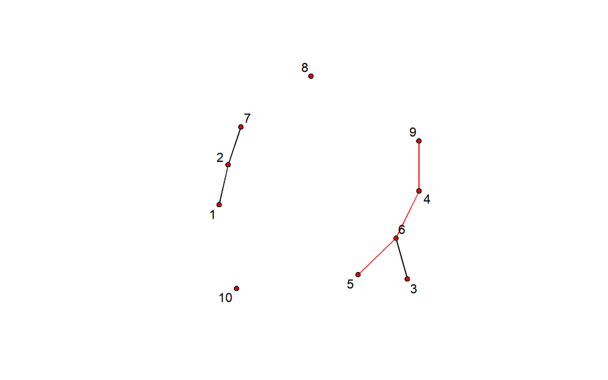

```r
# plot missnet with missing edge colored red.
tempnet <- missnet
tempnet[4,6] <- tempnet[4,9] <- tempnet[5,6] <- 1
missnetmat <- as.matrix(missnet)
missnetmat[is.na(missnetmat)] <- 2
plot(tempnet,label = network.vertex.names(tempnet),edge.col = missnetmat)
```

```r
summary(missnet~edges)
```

```
edges
    3
```

```r
summary(ergm(missnet~edges))
```

```
Evaluating log-likelihood at the estimate.
```

```
==========================
Summary of model fit
==========================

Formula:   missnet ~ edges

Iterations:  5 out of 20

Monte Carlo MLE Results:
      Estimate Std. Error MCMC %  p-value
edges  -2.5649     0.5991      0 0.000109 ***
---
Signif. codes:  0 '***' 0.001 '**' 0.01 '*' 0.05 '.' 0.1 ' ' 1

     Null Deviance: 58.22  on 42  degrees of freedom
 Residual Deviance: 21.61  on 41  degrees of freedom

AIC: 23.61    BIC: 25.35    (Smaller is better.)
```

The coefficient equals -2.56, which corresponds to a probability of 7.14%. Our network has 3 ties, out of the 42 non-missing nodal pairs (10 choose 2 minus 3): 3/42 = 7.14%. So our estimate represents the probability of a tie in the observed sample.

Now let’s assign those missing ties the value “0” and see what happens.

```r
missnet_bad <- missnet
missnet_bad[4,6] <- missnet_bad[4,9] <- missnet_bad[5,6] <- 0
summary(missnet_bad)
```

```
Network attributes:
  vertices = 10
  directed = FALSE
  hyper = FALSE
  loops = FALSE
  multiple = FALSE
  bipartite = FALSE
 total edges = 3
   missing edges = 0
   non-missing edges = 3
 density = 0.06666667

Vertex attributes:
  vertex.names:
   character valued attribute
   10 valid vertex names

No edge attributes

Network adjacency matrix:
   1 2 3 4 5 6 7 8 9 10
1  0 1 0 0 0 0 0 0 0  0
2  1 0 0 0 0 0 1 0 0  0
3  0 0 0 0 0 1 0 0 0  0
4  0 0 0 0 0 0 0 0 0  0
5  0 0 0 0 0 0 0 0 0  0
6  0 0 1 0 0 0 0 0 0  0
7  0 1 0 0 0 0 0 0 0  0
8  0 0 0 0 0 0 0 0 0  0
9  0 0 0 0 0 0 0 0 0  0
10 0 0 0 0 0 0 0 0 0  0
```

```r
summary(ergm(missnet_bad~edges))
```

```
Evaluating log-likelihood at the estimate.
```

```
==========================
Summary of model fit
==========================

Formula:   missnet_bad ~ edges

Iterations:  5 out of 20

Monte Carlo MLE Results:
      Estimate Std. Error MCMC % p-value
edges  -2.6391     0.5976      0  <1e-04 ***
---
Signif. codes:  0 '***' 0.001 '**' 0.01 '*' 0.05 '.' 0.1 ' ' 1

     Null Deviance: 62.38  on 45  degrees of freedom
 Residual Deviance: 22.04  on 44  degrees of freedom

AIC: 24.04    BIC: 25.85    (Smaller is better.)
```

The coefficient is smaller now because the missing ties are counted as “0”, and this translates to a conditional tie probability of 6.67%.  
It’s a small difference in this case (and a small network, with little missing data).

MORAL: If you have missing data on ties, be sure to identify them by assigning the “NA” code. This is particularly important if you’re reading in data as an edgelist, as all dyads without edges are implicitly set to “0” in this case.

## 3. Model terms available for *ergm* estimation and simulation

Model terms are the expressions (e.g. “triangle”) used to represent predictors on the right-hand size of equations used in:

- calls to `summary` (to obtain measurements of network statistics on a dataset)
- calls to `ergm` (to estimate an ergm model)
- calls to `simulate` (to simulate networks from an ergm model fit)

Because these terms are not exogeneous measures, but functions of the dyad states in the network, they must be calculated for the network that is being modeled. Many ERGM terms are simple counts of configurations (e.g., edges, nodal degrees, stars, triangles), but others are more complex functions of these configurations (e.g., geometrically weighted degrees and shared partners). In theory, any configuration (or function of configurations) can be a term in an ERGM. In practice, however, these terms have to be constructed before they can be used—that is, one has to explicitly write an algorithm that defines and calculates the network statistic of interest. This is another key way that ERGMs differ from traditional linear and general linear models.

The terms that can be used in a model also depend on the type of network being analyzed: directed or undirected, one-mode or two-mode (“bipartite”), binary or valued edges.

### Terms provided with ergm

For a list of available terms that can be used to specify an ERGM, type:

```r
help('ergm-terms')
```

A table of commonly used terms can be found [here](https://statnet.github.io/nme/d2-ergmterms.html)

A more complete discussion of many of these terms can be found in the ‘Specifications’ paper in the [*Journal of Statistical Software v24(4)*](http://www.jstatsoft.org/v24/i04)

Finally, note that models with only dyad independent terms are estimated in statnet using a logistic regression algorithm to maximize the likelihood. Dyad dependent terms require a different approach to estimation, which, in statnet, is based on a Monte Carlo Markov Chain (MCMC) algorithm that stochastically approximates the Maximum Likelihood.

### Coding new ergm-terms

There is a `statnet` package — `ergm.userterms` — that provides the utilities needed to write new ergm-terms. The package is available on CRAN, and installing it will include the tutorial (ergmuserterms.pdf). The tutorial can also be found in the [*Journal of Statistical Software 52(2)*](http://www.jstatsoft.org/v52/i02), and some introductory slides from the workshop we teach on coding ergm-terms can be found [here](https://statnet.csde.washington.edu/trac/attachment/wiki/Sunbelt2013/EUT%20tutorial%20slides.pptx).

Note that writing up new `ergm` terms requires some knowledge of C and the ability to build R from source. While the latter is covered in the tutorial, the many environments for building R and the rapid changes in these environments make these instructions obsolete quickly.

## 4. Network simulation: the *simulate* command and *network.list* objects

Once we have estimated the coefficients of an ERGM, the model is completely specified. It defines a probability distribution across all networks of this size. If the model is a good fit to the observed data, then networks drawn from this distribution will be more likely to “resemble” the observed data. To see examples of networks drawn from this distribution we use the `simulate` command:

```r
flomodel.03.sim <- simulate(flomodel.03,nsim=10)
class(flomodel.03.sim)
```

```
[1] "network.list"
```

```r
summary(flomodel.03.sim)
```

```
Number of Networks: 10
Model: flomarriage ~ edges + nodecov("wealth")
Reference: ~Bernoulli
Constraints: ~.
Parameters:
         edges nodecov.wealth
   -2.59492903     0.01054591

Stored network statistics:
      edges nodecov.wealth
 [1,]    22           2305
 [2,]    21           2053
 [3,]    27           3233
 [4,]    26           2994
 [5,]    18           1763
 [6,]    14           1874
 [7,]    23           2443
 [8,]    18           1646
 [9,]    18           2007
[10,]    22           1953
```

```r
length(flomodel.03.sim)
```

```
[1] 10
```

```r
flomodel.03.sim[[1]]
```

```
 Network attributes:
  vertices = 16
  directed = FALSE
  hyper = FALSE
  loops = FALSE
  multiple = FALSE
  bipartite = FALSE
  total edges= 22
    missing edges= 0
    non-missing edges= 22

 Vertex attribute names:
    priorates totalties vertex.names wealth

No edge attributes
```

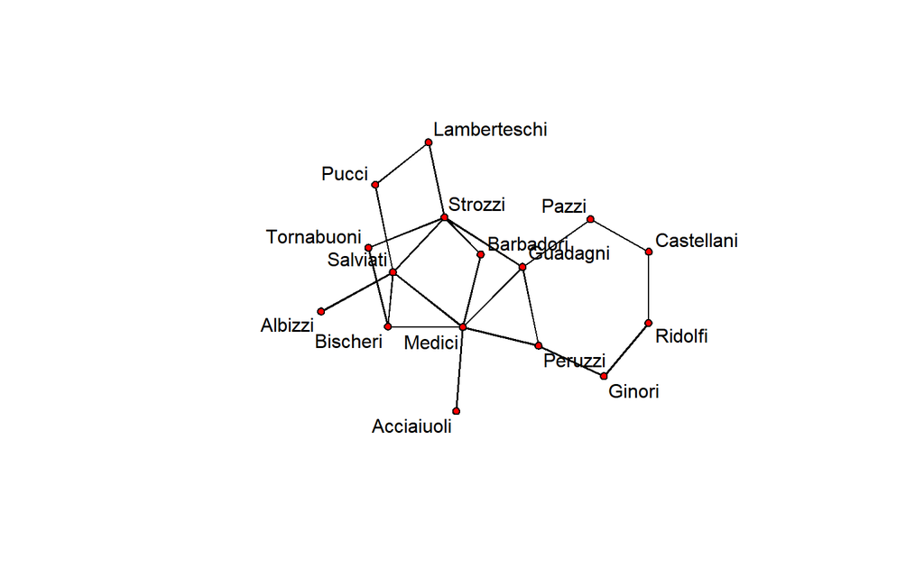

```r
plot(flomodel.03.sim[[1]], label= flomodel.03.sim[[1]] %v% "vertex.names")
```

Voila. Of course, yours will look somewhat different.

Simulation can be used for many purposes: to examine the range of variation that could be expected from this model, both in the sufficient statistics that define the model, and in other statistics not explicitly specified by the model. Simulation will play a large role in analyizing egocentrically sampled data in section 7 below. And if you take the `tergm` workshop, you will see how we can use simulation to examine the temporal implications of a model based on a single cross-sectional egocentrically sampled dataset.

For now, we will examine one of the primary uses of simulation in the ergm package: using simulated data from the model to evaluate goodness of fit to the observed data.

## 5. Examining the quality of model fit – GOF

ERGMs can be seen as generative models when they represent the process that governs the global patterns of tie prevalence from a local perspective: the perspective of the nodes involved in the particular micro-configurations represented by the ergm-terms in the model. The locally generated processes in turn aggregate up to produce characteristic global network properties, even though these global properties are not explicit terms in the model.

One test of whether a local model “fits the data” is therefore how well it reproduces the observed global network properties *that are not in the model*. We do this by choosing a network statistic that is not in the model, and comparing the value of this statistic observed in the original network to the distribution of values we get in simulated networks from our model, using the **gof** function.

The **gof** function is a bit different than the **summary**, **ergm**, and **simulate** functions, in that it currently only takes 3 ergm-terms as arguments: degree, esp (edgwise share partners), and distance (geodesic distances). Each of these terms captures an aggregate network distribution, at either the node level (degree), the edge level (esp), or the dyad level (distance).

```r
flomodel.03.gof <- gof(flomodel.03~degree + esp + distance)
flomodel.03.gof
```

```
Goodness-of-fit for degree

  obs min mean max MC p-value
0   1   0 1.39   5       1.00
1   4   0 3.46   9       0.94
2   2   0 3.88   9       0.52
3   6   1 3.71   9       0.24
4   2   0 1.84   5       1.00
5   0   0 0.98   3       0.72
6   1   0 0.42   2       0.80
7   0   0 0.21   1       1.00
8   0   0 0.11   2       1.00

Goodness-of-fit for edgewise shared partner

     obs min  mean max MC p-value
esp0  12   3 11.92  21       1.00
esp1   7   0  5.97  16       0.88
esp2   1   0  1.54   9       1.00
esp3   0   0  0.22   3       1.00
esp4   0   0  0.08   2       1.00
esp5   0   0  0.01   1       1.00

Goodness-of-fit for minimum geodesic distance

    obs min  mean max MC p-value
1    20  11 19.74  31       0.96
2    35  12 33.03  54       0.90
3    32   9 26.01  43       0.48
4    15   1 11.81  28       0.78
5     3   0  3.56  18       0.94
6     0   0  0.84  10       1.00
7     0   0  0.07   5       1.00
8     0   0  0.02   2       1.00
Inf  15   0 24.92  81       1.00
```

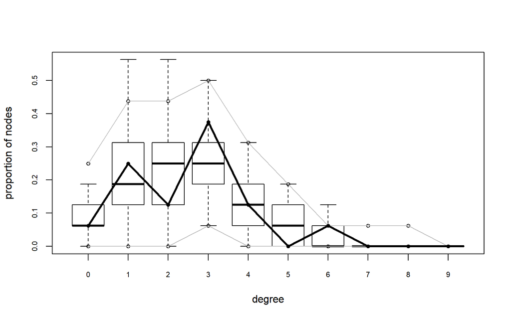

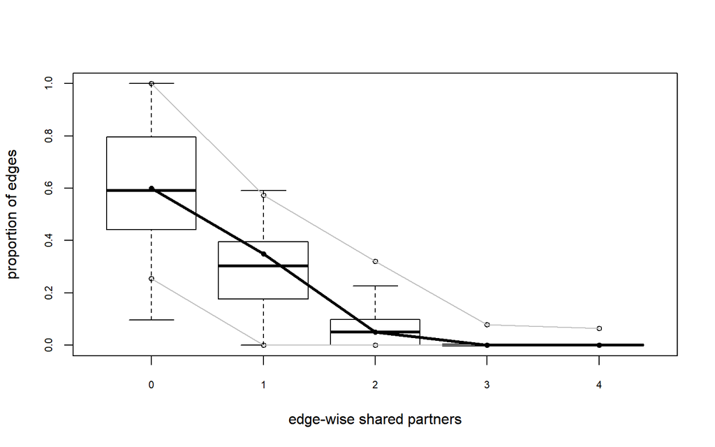

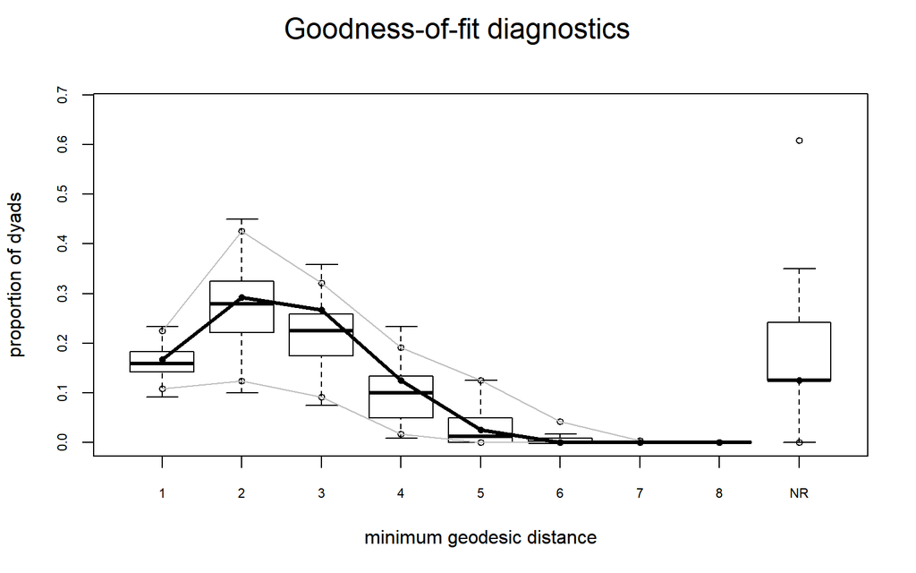

```r
plot(flomodel.03.gof)
```

```r
mesamodel.02 <- ergm(mesa~edges)
```

```
Evaluating log-likelihood at the estimate.
```

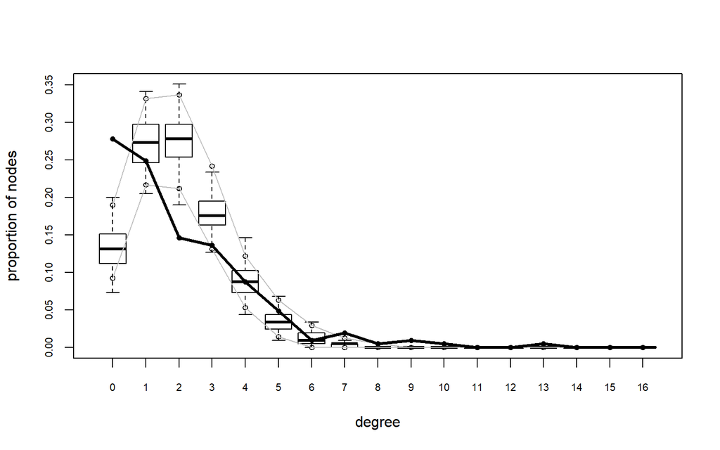

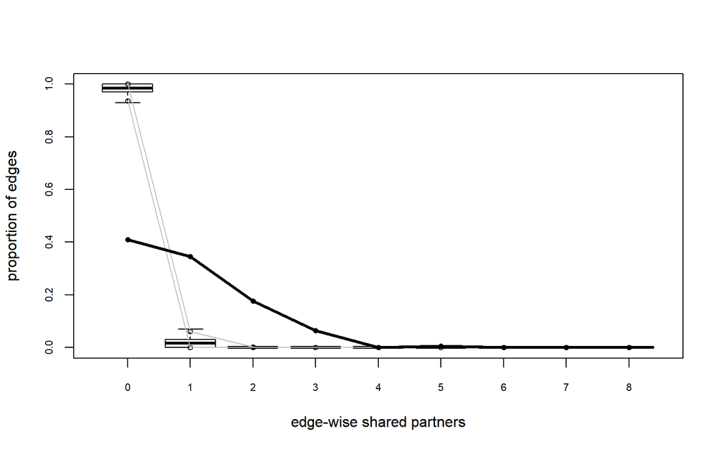

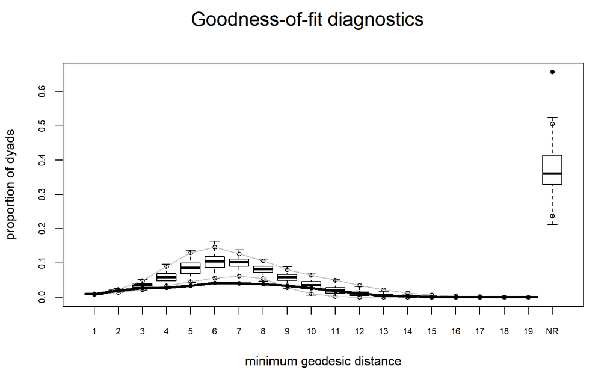

```r
mesamodel.02.gof <- gof(mesamodel.02~degree + esp + distance,
                        control.gof.formula(nsim=10))
plot(mesamodel.02.gof)
```

For a good example of model exploration and fitting for the Add Health Friendship networks, see [Goodreau, Kitts & Morris, *Demography* 2009](http://link.springer.com/article/10.1353/dem.0.0045).  
For more technical details on the approach, see [Hunter, Goodreau and Handcock *JASA* 2008](http://amstat.tandfonline.com/doi/abs/10.1198/016214507000000446?journalCode=uasa20#.U7HZgPldWSo)

## 6. Diagnostics: troubleshooting and checking for model degeneracy

The computational algorithms in `ergm` use MCMC (with a Metropolis-Hastings sampler) to estimate the likelihood function when dyad dependent terms are in the model. Part of this process involves simulating a set of networks to use as a sample for approximating the unknown component of the likelihood: the $k(\theta)$ term in the denominator.

When a model is not a good representation of the observed network, these simulated networks may be far enough away from the observed network that the estimation process is affected. In the worst case scenario, the simulated networks will be so different that the algorithm fails altogether.

For more detailed discussion of model degeneracy in the ERGM context, see the papers by Mark Handcock referenced below.

In the worst case scenario, we end up not being able to obtain coefficent estimates, so we can’t use the GOF function to identify how the model simulations deviate from the observed data. In this case, however, we can use the MCMC diagnostics to observe what is happening with the simulation algorithm, and this (plus some experience and intuition about the behavior of ergm-terms) can help us improve the model specification.

Below we show a simple example of a model that converges, and one that doesn’t, and how to use the MCMC diagnostics to improve a model that isn’t converging.

### What it looks like when a model converges properly

We will first consider a simulation where the algorithm works using the program defaults, and observe the behavior of the MCMC estimation algorithm using the `mcmc.diagnostics` function.

```r
summary(flobusiness~edges+degree(1))
```

```
  edges degree1
     15       3
```

```r
fit <- ergm(flobusiness~edges+degree(1))
mcmc.diagnostics(fit)
```

```
Sample statistics summary:

Iterations = 16384:4209664
Thinning interval = 1024
Number of chains = 1
Sample size per chain = 4096

1. Empirical mean and standard deviation for each variable,
   plus standard error of the mean:

            Mean    SD Naive SE Time-series SE
edges   -0.16235 3.776  0.05900        0.05721
degree1 -0.02441 1.656  0.02587        0.02587

2. Quantiles for each variable:

        2.5% 25% 50% 75% 97.5%
edges     -8  -3   0   2     7
degree1   -3  -1   0   1     4


Sample statistics cross-correlations:
             edges    degree1
edges    1.0000000 -0.4469011
degree1 -0.4469011  1.0000000

Sample statistics auto-correlation:
Chain 1
                edges      degree1
Lag 0     1.000000000  1.000000000
Lag 1024 -0.030943830 -0.006906477
Lag 2048  0.006677487  0.025075410
Lag 3072 -0.006159053  0.002537837
Lag 4096 -0.005477645 -0.002805939
Lag 5120 -0.011692893 -0.016094690

Sample statistics burn-in diagnostic (Geweke):
Chain 1

Fraction in 1st window = 0.1
Fraction in 2nd window = 0.5

  edges degree1
  0.964   1.476

Individual P-values (lower = worse):
    edges   degree1
0.3350686 0.1398374
Joint P-value (lower = worse):  0.0800707 .
```

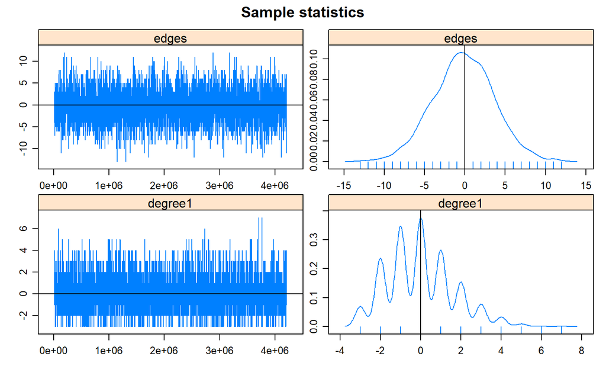

```
MCMC diagnostics shown here are from the last round of simulation, prior to computation of final parameter estimates. Because the final estimates are refinements of those used for this simulation run, these diagnostics may understate model performance. To directly assess the performance of the final…
```

This is what you want to see in the MCMC diagnostics: the MCMC sample statistics are varying randomly around the observed values at each step (so the chain is “mixing” well) and the difference between the observed and simulated values of the sample statistics have a roughly bell-shaped distribution, centered at 0. The sawtooth pattern visible on the degree term deviation plot is due to the combination of discrete values and small range in the statistics: the observed number of degree 1 nodes is 3, and only a few discrete values are produced by the simulations. So the sawtooth pattern is is an inherent property of the statistic, not a problem with the fit.

There are many control parameters for the MCMC algorithm (“help(control.ergm)”), and we’ll play with some of these below. To see what the algorithm is doing at each step, you can drop the sampling interval down to 1:

```r
fit <- ergm(flobusiness~edges+degree(1),
            control=control.ergm(MCMC.interval=1))
```

This runs a version with every network returned, and might be useful if you are trying to debug a bad model fit.

### What it looks like when a model fails

Now let us look at a more problematic case, using a larger network:

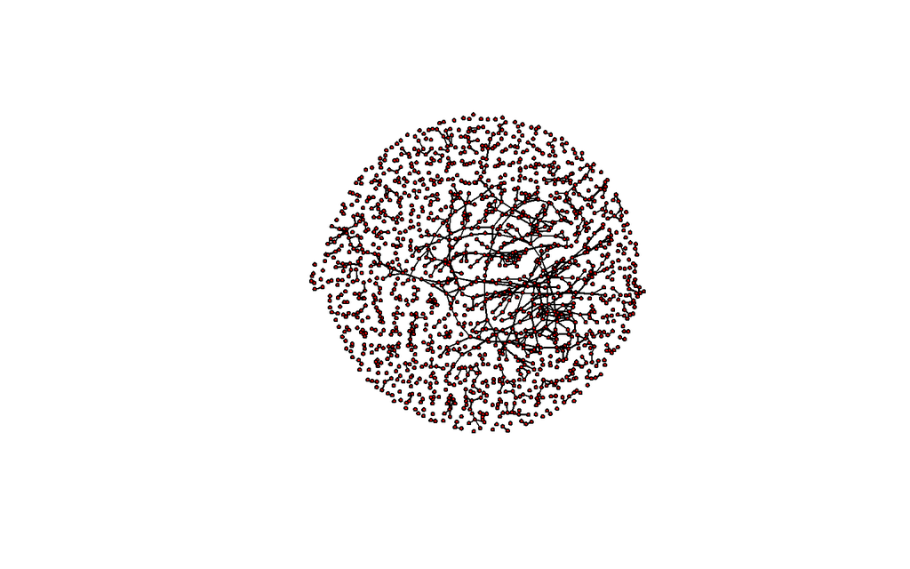

```r
data('faux.magnolia.high')
magnolia <- faux.magnolia.high
plot(magnolia, vertex.cex=.5)
```

```r
summary(magnolia~edges+triangle)
```

```
   edges triangle
     974      169
```

But, if we try to fit this “simple” model:

```r
fit <- ergm(magnolia~edges+triangle)
```

```
Iteration 1 of at most 20:
Convergence test P-value: 1.4e-87
The log-likelihood improved by 1.183
Iteration 2 of at most 20:
Convergence test P-value: 3.8e-04
The log-likelihood improved by 0.1518
Iteration 3 of at most 20:
```

```
Error: Number of edges in a simulated network exceeds that in the observed by a factor of more than 20. This is a strong indicator of model degeneracy. If you are reasonably certain that this is not the case, increase the MCMLE.density.guard control.ergm() parameter.
```

Very interesting. In the process of trying to fit this model, the algorithm heads off into networks that are much much more dense than the observed network. This is such a clear indicator of a degenerate model specification that the algorithm stops after 3 iterations, to avoid heading off into areas that would cause memory issues. If you’d like to peek a bit more under the hood, you can stop the algorithm earlier to catch where it’s heading:

```r
fit <- ergm(magnolia~edges+triangle, control=control.ergm(MCMLE.maxit=2))
```

```
Starting maximum likelihood estimation via MCMLE:

Iteration 1 of at most 2:
Optimizing with step length 0.707275631968435.
The log-likelihood improved by 8.688.

Iteration 2 of at most 2:
Optimizing with step length 1.
The log-likelihood improved by 3.539.

Step length converged once. Increasing MCMC sample size.

MCMLE estimation did not converge after 2 iterations. The estimated coefficients may not be accurate. Estimation may be resumed by passing the coefficients as initial values; see 'init' under ?control.ergm for details.

 ... (output snipped)

This model was fit using MCMC.  To examine model diagnostics and check for degeneracy, use the mcmc.diagnostics() function.
```

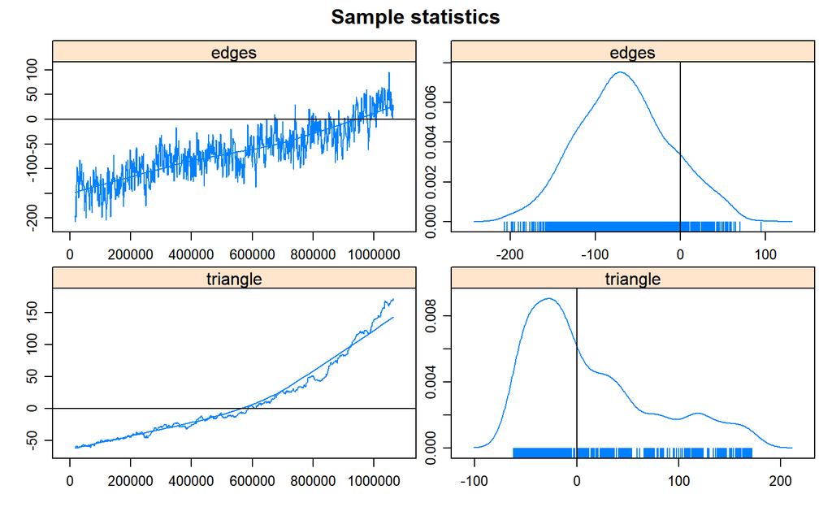

```r
mcmc.diagnostics(fit)
```

Clearly, somewhere very bad.

How about trying the more robust version of modeling triangles: the geometrically-weighed edgewise shared partner term (GWESP)? (For a technical introduction to GWESP see [Hunter and Handcock, 2006](http://www.tandfonline.com/doi/abs/10.1198/106186006X133069#.U6R5WfldWSo); for a more intuitive description and empirical application see [Goodreau, Kitts & Morris, 2009](http://link.springer.com/article/10.1353/dem.0.0045) )

```r
fit <- ergm(magnolia~edges+gwesp(0.25,fixed=T),verbose=T)
```

```
Sampler accepted  67.306% of 1048576 proposed steps.
Sampler accepted  62.746% of 1048576 proposed steps.
Sampler accepted  60.057% of 1048576 proposed steps.
Sampler accepted  65.515% of 4194304 proposed steps.
```

```r
mcmc.diagnostics(fit)
```

```
Sample statistics summary:

Iterations = 16384:4209664
Thinning interval = 1024
Number of chains = 1
Sample size per chain = 4096

1. Empirical mean and standard deviation for each variable,
   plus standard error of the mean:

                   Mean    SD Naive SE Time-series SE
edges            -48.89 38.82   0.6066          7.866
gwesp.fixed.0.25 -52.64 30.47   0.4760         10.052

2. Quantiles for each variable:

                   2.5%    25%    50%   75% 97.5%
edges            -119.0 -76.00 -52.00 -24.0 33.00
gwesp.fixed.0.25 -100.7 -77.08 -52.61 -36.6 14.77


Sample statistics cross-correlations:
                     edges gwesp.fixed.0.25
edges            1.0000000        0.7684542
gwesp.fixed.0.25 0.7684542        1.0000000

Sample statistics auto-correlation:
Chain 1
             edges gwesp.fixed.0.25
Lag 0    1.0000000        1.0000000
Lag 1024 0.8267218        0.9955233
Lag 2048 0.7310688        0.9911892
Lag 3072 0.6717042        0.9870599
Lag 4096 0.6346548        0.9829636
Lag 5120 0.6102523        0.9790446

Sample statistics burn-in diagnostic (Geweke):
Chain 1

Fraction in 1st window = 0.1
Fraction in 2nd window = 0.5

           edges gwesp.fixed.0.25
           9.569            8.033

Individual P-values (lower = worse):
           edges gwesp.fixed.0.25
    1.080726e-21     9.484223e-16
Joint P-value (lower = worse):  0.001516495 .
```

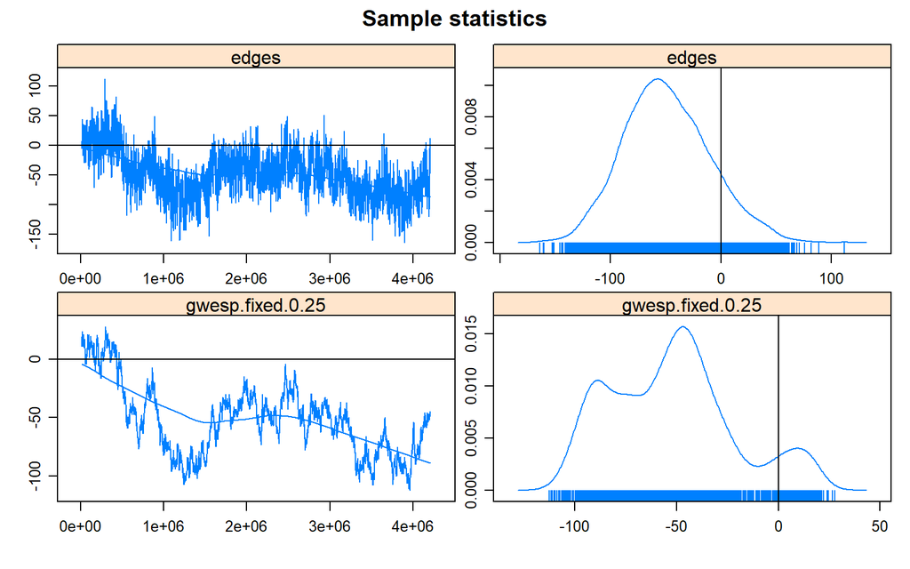

```
MCMC diagnostics shown here are from the last round of simulation, prior to computation of final parameter estimates. Because the final estimates are refinements of those used for this simulation run, these diagnostics may understate model performance. To directly assess the performance of the final…
```

[output not shown]

Better, but not great. Here we’ll change two things – add some more reasonable terms to the model, and add in some robustness to the fitting algorithm by making the MCMC simulation longer.

```r
fit <- ergm(magnolia~edges+gwesp(0.25,fixed=T)+nodematch('Grade')+
              nodematch('Race')+nodematch('Sex'),
            control = control.ergm(MCMC.samplesize=50000,
                                   MCMC.interval=1000),
            verbose=T)
```

```
Evaluating network in model.
```

```
Initializing Metropolis-Hastings proposal(s): ergm:MH_TNT
Using initial method 'MPLE'.
Fitting initial model.
MPLE covariate matrix has 211 rows.
Fitting ERGM.
Starting maximum likelihood estimation via MCMLE:
Density guard set to 19563 from an initial count of 974 edges.

Iteration 1 of at most 20 with parameter:
           edges gwesp.fixed.0.25  nodematch.Grade   nodematch.Race
      -9.8619687        1.6946112        2.8534613        0.9886313
   nodematch.Sex
       0.8245285
```

```
Sampler accepted  30.444% of 50000000 proposed steps.
```

```
Sample size = 50000 by 50000.
Back from unconstrained MCMC. Average statistics:
           edges gwesp.fixed.0.25  nodematch.Grade   nodematch.Race
       104.50542         42.95520        102.77140        100.89348
   nodematch.Sex
        87.45524
Starting MCMLE Optimization...
Optimizing with step length 1.
Using lognormal metric (see control.ergm function).
Using log-normal approx (no optim)
The log-likelihood improved by 4.943.
Step length converged once. Increasing MCMC sample size.

Iteration 2 of at most 20 with parameter:
           edges gwesp.fixed.0.25  nodematch.Grade   nodematch.Race
      -9.7991219        1.7993887        2.7523455        0.9231004
   nodematch.Sex
       0.7793418
```

```
Sampler accepted  31.353% of 200000000 proposed steps.
```

```
Sample size = 200000 by 2e+05.
Back from unconstrained MCMC. Average statistics:
           edges gwesp.fixed.0.25  nodematch.Grade   nodematch.Race
        27.78893         26.07290         27.23695         27.70463
   nodematch.Sex
        24.74043
Starting MCMLE Optimization...
Optimizing with step length 1.
Using lognormal metric (see control.ergm function).
Using log-normal approx (no optim)
Starting MCMC s.e. computation.
The log-likelihood improved by 0.2216.
Step length converged twice. Stopping.
Evaluating log-likelihood at the estimate. Using 20 bridges: 1 2 3 4 5 6 7 8 9 10 11 12 13 14 15 16 17 18 19 20 .
This model was fit using MCMC.  To examine model diagnostics and check for degeneracy, use the mcmc.diagnostics() function.
```

```r
mcmc.diagnostics(fit)
```

```
Sample statistics summary:

Iterations = 16000:200015000
Thinning interval = 1000
Number of chains = 1
Sample size per chain = 2e+05

1. Empirical mean and standard deviation for each variable,
   plus standard error of the mean:

                  Mean    SD Naive SE Time-series SE
edges            27.79 50.41  0.11273          2.739
gwesp.fixed.0.25 26.07 46.95  0.10499          3.843
nodematch.Grade  27.24 48.16  0.10769          2.853
nodematch.Race   27.70 45.63  0.10204          2.561
nodematch.Sex    24.74 41.14  0.09199          2.165

2. Quantiles for each variable:

                   2.5%    25%   50%   75% 97.5%
edges            -67.00 -7.000 26.00 60.00 132.0
gwesp.fixed.0.25 -60.46 -6.689 24.29 55.41 125.5
nodematch.Grade  -62.00 -6.000 26.00 58.00 127.0
nodematch.Race   -57.00 -4.000 26.00 57.00 123.0
nodematch.Sex    -53.00 -3.000 24.00 51.00 110.0


Sample statistics cross-correlations:
                     edges gwesp.fixed.0.25 nodematch.Grade nodematch.Race
edges            1.0000000        0.8714065       0.9665097      0.9519157
gwesp.fixed.0.25 0.8714065        1.0000000       0.8889242      0.8644635
nodematch.Grade  0.9665097        0.8889242       1.0000000      0.9260056
nodematch.Race   0.9519157        0.8644635       0.9260056      1.0000000
nodematch.Sex    0.9165936        0.8206331       0.8894860      0.8743166
                 nodematch.Sex
edges                0.9165936
gwesp.fixed.0.25     0.8206331
nodematch.Grade      0.8894860
nodematch.Race       0.8743166
nodematch.Sex        1.0000000
```

[output cut: 20 more lines]

```

Fraction in 1st window = 0.1
Fraction in 2nd window = 0.5

           edges gwesp.fixed.0.25  nodematch.Grade   nodematch.Race
           3.107            2.313            2.891            2.983
   nodematch.Sex
           3.342

Individual P-values (lower = worse):
           edges gwesp.fixed.0.25  nodematch.Grade   nodematch.Race
    0.0018910749     0.0207264854     0.0038353298     0.0028555378
   nodematch.Sex
    0.0008320123
Joint P-value (lower = worse):  0.2294871 .
```

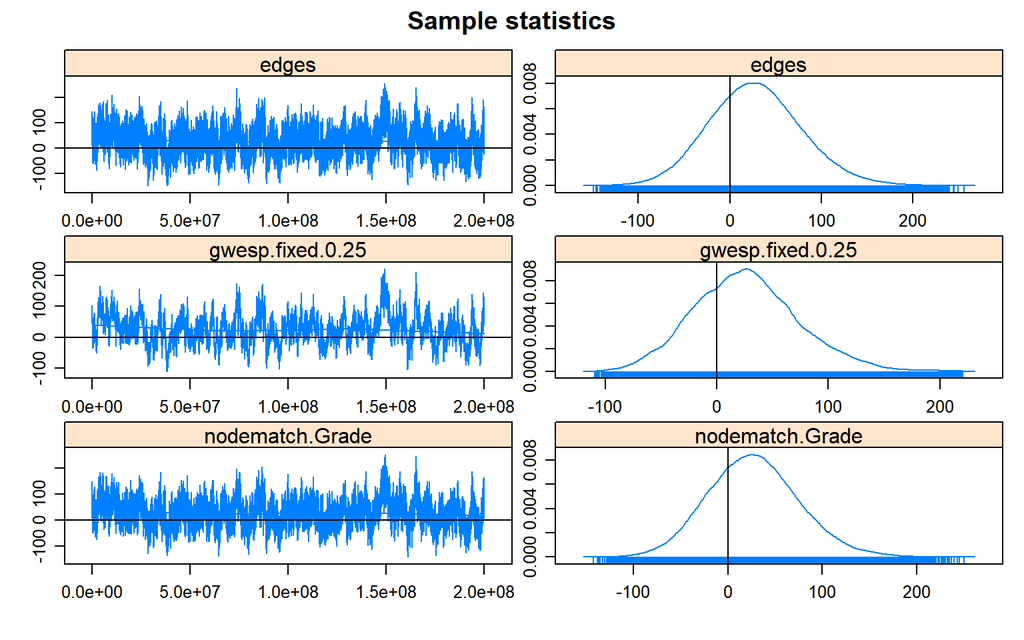

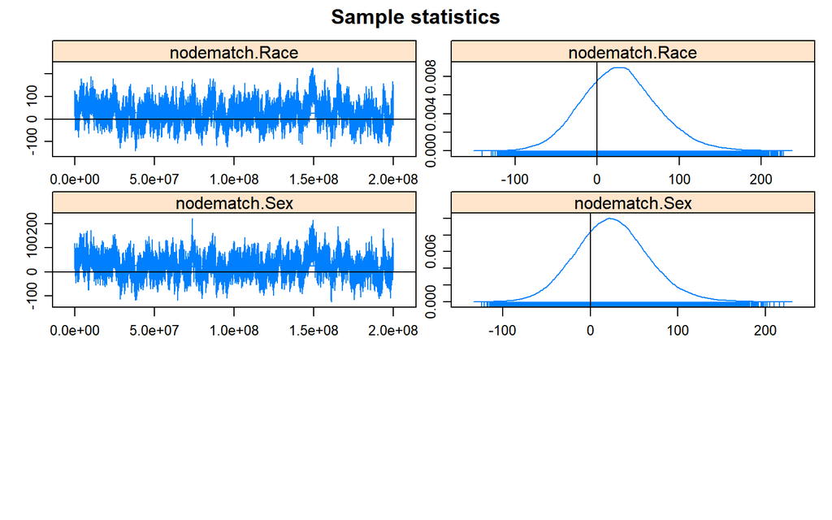

```
MCMC diagnostics shown here are from the last round of simulation, prior to computation of final parameter estimates. Because the final estimates are refinements of those used for this simulation run, these diagnostics may understate model performance. To directly assess the performance of the final…
```

Success! Of course, in real life one might have a lot more trial and error.

**MORAL:** Degeneracy is an indicator of a poorly specified model. It is not a property of all ERGMs, but it is associated with some dyadic-dependent terms, in particular, the reduced homogenous Markov specifications (e.g., 2-stars and triangle terms). For a good technical discussion of unstable terms see [Schweinberger 2012.](http://www.tandfonline.com/doi/abs/10.1198/jasa.2011.tm10747#.U6R2FvldWSo) For a discussion of alternative terms that exhibit more stable behavior see [Snijders et al. 2006.](http://onlinelibrary.wiley.com/doi/10.1111/j.1467-9531.2006.00176.x/abstract) and for the gwesp term (and the curved exponential family terms in general) see [Hunter and Handcock 2006.](http://amstat.tandfonline.com/doi/abs/10.1198/106186006X133069#.U7MxWPldWSo)

## 7. Working with egocentrically sampled network data

One of the most powerful features of ERGMs is that they can be used to estimate models from from egocentrically sampled data, and the fitted models can then be used to simulate complete networks (of any size) that will have the properties of the original network that are observed and represented in the model.

In many empirical contexts, it is not feasible to collect a network census or even an adaptive (link-traced) sample. Even when one of these may be possible in practice, egocentrically sampled data are typically cheaper and easier to collect.

Long regarded as the poor country cousin in the network data family, egocentric data contain a remarkable amount of information. With the right statistical methods, such data can be used to explore the properties of the complete networks in which they are embedded. The basic idea here is to combine what is observed, with assumptions, to define a class of models that describe the distribution of networks that are centered on the observed properties. The variation in these networks quantifies some of the uncertainty introduced by the assumptions.

The egocentric estimation/simulation framework extends to temporal ERGMs (“TERGMs”) as well, with the minimal addition of an estimate of partnership duration. This makes it possible to simulate complete dynamic networks from a single cross-sectional egocentrically sampled network. For an example of what you can do with this, check out the network movie we developed to explore the impact of dynamic network structure on HIV transmission, see http://statnet.org/movies

While the `ergm` package has had this capability for many years (and old ERGM worshops had a section on this), there is now a specific package that makes this much easier: `ergm.ego`. The new package includes accurate statistical inference (so you can get standard errors for model coefficients), and many utilities that simplify the task of reading in the data, conducting exploratory analyses, and specifying model options.

We now have a separate workshop/tutorial for `ergm.ego`, so we no longer cover this material in the current ERGM workshop. As always, this workshop material can be found online at the statnet wiki.

## 8. Additional functionality in statnet and other packages

`statnet` is actually a suite of packages that are designed to work together, and provide tools for a wide range of different types of network data analysis. Examples include temporal network models and dynamic network vizualizations, analysis of egocentrically sampled network data, multilevel network modeling, latent cluster models and network diffusion and epidemic models. Development is ongoing, and there are new packages, and new functionality added to existing packages on a regular basis.

All of these packages can be downloaded from CRAN. For more detailed information, please visit the `statnet` webpage [www.statnet.org](http://statnet.org).

### Current statnet packages

Packages developed by statnet team that are not covered in this tutorial:

- `sna` – classical social network analysis utilities
- `tsna` – descriptive statistics for temporal network data
- `tergm` – temporal ergms for dynamic networks
- `ergm.ego`– estimation/simulation of ergms from egocentrically sampled data
- `ergm.count` – models for tie count network data
- `ergm.rank` – models for tie rank network data
- `relevent` – relational event models for networks
- `latentnet` – latent space and latent cluster analysis
- `degreenet` – MLE estimation for degree distributions (negative binomial, Poisson, scale-free, etc.)
- `networksis` – simulation of bipartite networks with given degree distributions
- `ndtv` package – network movie maker
- `EpiModel` – network modeling of infectious disease and social diffusion processes

Many of these have associated training workshops. Our tutorials can be found online, either on the [new GitHub statnet wiki](https://statnet.github.io/Workshops) or the [old statnet wiki](https://statnet.csde.washington.edu/trac). Everything will eventually be moved over to the GitHub wiki

### Additional functionality in base ergm

- ERGMs for valued ties

### Extensions by other developers

There are now a number of excellent packages developed by others that extend the functionality of statnet. The easiest way to find these is to look at the “reverse depends” of the `ergm` package on [CRAN](https://cran.org/packages). Examples include:

- `Bergm` – Bayesian Exponential Random Graph Models
- `btergm` – Temporal Exponential Random Graph Models by Bootstrapped Pseudolikelihood
- `hergm` – hierarchical ERGMs for multi-level network data
- `xergm` – extensions to ERGM modeling

### Statnet Commons: The development group

Mark S. Handcock handcock@stat.ucla.edu  
David R. Hunter dhunter@stat.psu.edu  
Carter T. Butts buttsc@uci.edu  
Steven M. Goodreau goodreau@u.washington.edu  
Skye Bender-deMoll skyebend@skyeome.net  
Martina Morris morrism@u.washington.edu  
Pavel N. Krivitsky pavel@uow.edu.au  
Samuel M. Jenness samuel.m.jenness@emory.edu

## Appendix A: Clarifying the terms – ergm and network

You will see the terms ergm and network used in multiple contexts throughout the documentation. This is common in R, but often confusing to newcomers. To clarify:

**ergm**

- **ERGM**: the acronym for an Exponential Random Graph Model; a statistical model for relational data that takes a generalized exponential family form.
- **ergm package**: one of the packages within the `statnet` suite
- **ergm function**: a function within the ergm package; fits an ERGM to a network object, creating an ergm object in the process.
- **ergm object**: a class of objects produced by a call to the ergm function, representing the results of an ERGM fit to a network.

**network**

- **network**: a set of actors and the relations among them. Used interchangeably with the term graph.
- **network package**: one of the packages within the `statnet` suite; used to create, store, modify and plot the information found in network objects.
- **network object**: a class of object in `R` used to represent a network.

## References

The best place to start is the special issue of the *Journal of Statistical Software* (JSS) devoted to `statnet`: [link](https://www.jstatsoft.org/issue/view/v024)

The nine papers in this issue cover a wide range of theoretical and practical topics related to ERGMs, and their implementation in `statnet`.

HOWEVER: Note that this issue was written in 2008. The statnet code base has evolved considerably since that time, so some of the syntax specified in the articles may no longer work (in most cases because it has been replace with something better).

For social scientists, a good introductory application paper is:

Goodreau, S., J. Kitts and M. Morris (2009). Birds of a Feather, or Friend of a Friend? Using Statistical Network Analysis to Investigate Adolescent Social Networks. *Demography* 46(1): 103-125. [link](http://link.springer.com/article/10.1353/dem.0.0045)

** Dealing with Model Degeneracy **

Handcock MS (2003a). “Assessing Degeneracy in Statistical Models of Social Networks.” Working Paper 39, Center for Statistics and the Social Sciences, University of Washington. [link](http://www.csss.washington.edu/Papers/)

Schweinberger, Michael (2011) Instability, Sensitivity, and Degeneracy of Discrete Exponential Families *JASA* 106(496): 1361-1370. [link](http://www.tandfonline.com/doi/abs/10.1198/jasa.2011.tm10747#.U7M4A_ldWSo)

Snijders, TAB et al (2006) New Specifications For Exponential Random Graph Models  
*Sociological Methodology* 36(1): 99-153 [link](http://onlinelibrary.wiley.com/doi/10.1111/j.1467-9531.2006.00176.x/abstract)

Hunter, D. R. (2007). Curved Exponential Family Models for Social Networks. *Social Networks*, 29(2), 216-230.

** Temporal ERGMs **

Krivitsky, P.N., Handcock, M.S,(2014). A separable model for dynamic networks *JRSS Series B-Statistical Methodology*, 76(1):29-46; 10.1111/rssb.12014 JAN 2014 [link](http://onlinelibrary.wiley.com/doi/10.1111/rssb.12014/abstract)

Krivitsky, P. N., M. S. Handcock and M. Morris (2011). Adjusting for Network Size and Composition Effects in Exponential-family Random Graph Models, *Statistical Methodology* 8(4): 319-339, ISSN 1572-3127 [link](http://www.sciencedirect.com/science/article/pii/S1572312711000086)

** Egocentric ERGMS **

Krivitsky, P. N., & Morris, M. (2017). Inference for social network models from egocentrically sampled data, with application to understanding persistent racial disparities in HIV prevalence in the US. *Annals of Applied Statistics*, 11(1), 427-455.